# Flu model documentation

Fanny Bergström

2024-06-10

## Introduction

This document describes an age and vaccination dissaggregated SIR model. We are fitting the model to weekly ILI incidence multiplied by flu-positivity in that same week.

## SIR

We consider a population consisting of $N$ individuals. The population is divided into three compartments: the susceptible, infectious and removed compartments. Their sizes, at any time $t$ for an age class $j$, are denoted by $S^{(j)}(t)$, $I^{(j)}(t)$ and $R^{(j)}(t)$ respectively. We also use a community contact rate $\beta$. We let the rate of recovery be denoted $\gamma$.

We use a contact matrix $C$, with elements $C_{i,j}$ being the average number of contacts an individual in age group $i$ has with individuals in age group $j$ within 24h.

We let $vax(t)$ be the fraction of new people being vaccinated on day $t$. Subscript $u$ and $v$ are used to distinguish between the unvaccinated and vaccinated groups. We further let $ve_{inf}$, $ve_{susc}$ and $ve_{severe}$ be the vaccine efficacy in terms of infectiousness, susceptibility and severe disease.

The SIR model is specified as follows

$$\begin{aligned}
S_u^{(j)}(t) & = S_u^{(j)}(t-1) - vax^{(j)}(t-1)
\frac{S_u^{(j)}(t-1) }{S_u^{(j)}(t-1) +R_u^{(j)}(t-1) }\\
& -\beta\sum_{i} C_{i,j} \big(I_u^{(i)}(t-1)+ (1-ve_{inf})
(I_{v}^{(i)}(t-1)\big) S_u^{(j)}(t-1) \\
\\
S_{v}^{(j)}(t) & = S_{v}^{(j)}(t-1) + vax^{(j)}(t-1)
\frac{S_u^{(j)}(t-1) }{S_u^{(j)}(t-1) +R_u^{(j)}(t-1) }\\
&-\beta\sum_{i} C_{i,j} \big(I_u^{(i)}(t-1)+ (1-ve_{inf})
(I_{v}^{(i)}(t-1)\big) S_{v}^{(j)(t-1)}(1-ve_{susc}) \\
\\
I_u^{(j)}(t) & = I_u^{(j)}(t-1)+ \beta\sum_{i}
C_{i,j} \big(I_u^{(i)}(t-1)+ (1-ve_{inf}) (I_{v}^{(i)}(t-1)\big)
S_u^{(j)}(t-1) - \gamma I_u^{(j)}(t - 1) \\
\\
I_{v}^{(j)}(t) & = I_{v}^{(j)}(t-1) + \beta\sum_{i}
C_{i,j} \big(I_u^{(i)}(t-1)+ (1-ve_{inf}) (I_{v}^{(i)}(t-1)\big)
S_{v}^{(j)}(t-1) - \gamma I_{v}^{(j)}(t - 1) \\
\\
R_u^{(j)}(t) & = R_u^{(j)}(t-1) + \gamma I_u^{(j)}(t - 1) -
vax^{(j)}(t-1) \frac{R_u^{(j)}(t-1) }{S_u^{(j)}(t-1) + R_u^{(j)}(t-1) }
\\
R_{v}^{(j)}(t) & = R_{v}^{(j)}(t-1) + \gamma I_{v}^{(j)}(t - 1) +
vax^{(j)}(t-1) \frac{R_u^{(j)}(t-1) }{S_u^{(j)}(t-1) + R_u^{(j)}(t-1) }.
\end{aligned}$$

Interpretation of the first equation: Let’s multiply both sides with the population size of the focus age group ($N^{(j)}$) to allow interpretation of this equation in terms of how the absolute number of susceptible, unvaccinated individuals of age group $j$ changes. The new number of susceptible, unvaccinated individuals of age group $j$ ($N^{(j)}S_u^{(j)}(t)$) is given through the number of such individuals in the previous time-step ($N_{j}S_u^{(j)}(t-1)$), minus those that were vaccinated and those that were infected.

```latex
\begin{aligned}
S_u^{(j)}(t) & = S_u^{(j)}(t-1) - vax^{(j)}(t-1) \frac{S_u^{(j)}(t-1) }{S_u^{(j)}(t-1) +R_u^{(j)}(t-1) }\\
& -\beta\sum_{i} C_{i,j}  \big(I_u^{(i)}(t-1)+ (1-ve_{inf}) (I_{v}^{(i)}(t-1)\big) S_u^{(j)}(t-1) \\
S_u^{(j)}(t) & = S_u^{(j)}(t-1) - vax^{(j)}(t-1) \frac{S_u^{(j)}(t-1) }{S_u^{(j)}(t-1) +R_u^{(j)}(t-1) }\\
& -\beta\gamma_{j}\sum_{i} C_{i,j}  \big(I_u^{(i)}(t-1)+ (1-ve_{inf}) (I_{v}^{(i)}(t-1)\big) S_u^{(j)}(t-1).


\end{aligned}
```

Here $\gamma_{j}$ is the age groups $j$ modifier of the country’s typical number of potentially infecting contacts.

We let both susceptible and recovered be vaccinated proportional to their size at time $t$, assuming that you will not get vaccinated during the time of being infectious.

## Statistical inference

We assume an Negative Binomial distribution for the weekly ILI incidence multiplied by the flu positivity for that week.

The SIR model is fitted on a daily scale and then

$$\text{weekly ILI for age group } i \text{ at time } t\sim \text{NegBin}(
\mu(t)^i, \phi ),$$
where $\mu(t)^i$ is the mean of the severe outcomes for age group $i$ for week $t$ and $\phi$ is the overdispersion parameter.

## Contact matrix

For the contact matrix $C$, we use country specific estimates from the study [“Projecting social contact matrices in 152 countries using contact surveys and demographic data” (Prem et al, 2017)](https://journals.plos.org/ploscompbiol/article?id=10.1371/journal.pcbi.1005697). This study provides model based estimates of the expected number of contacts of an individual in age-group $i$ with individuals from age-group $j$ within 24h.

The contact frequencies are provided in sixteen 5-year age-groups from age 0-4 until age 75-79.

Below is the contact matrix for Albania.

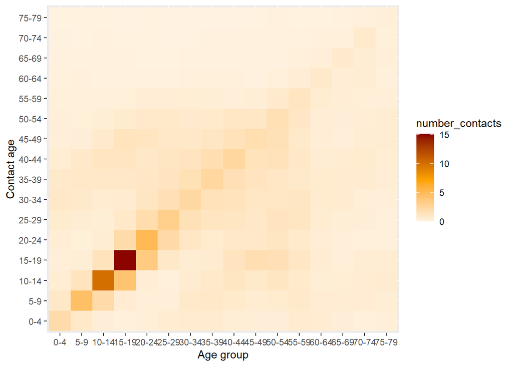

To specify new age groups we need to make some specific assumptions:

- The contact behavior within each 5-year age group is the same for all ages. Every member of an age-group $i$, e.g. 15-19 year old, has the same expected number of contacts with other age-groups.
- The contacts of an individual with age-group $i$ to individual with age (in years) $k$ from age-group $j$ occur with a expected frequency corresponding to the share of individuals with age $k$ years in age-group $j$.

Based on these assumptions and in combination with the age distribution of each country, we can derive a contact matrix with 1-year resolution in the age-range 0-79 years.

After obtaining this fine-grained contact matrix we can derive contact frequencies for arbitrary age-groups. For an individual of age $k$ years we can sum over all the expected contacts in each of the new age-groups $j$. To derive the expected number of contacts in a new age group $i$ with the age-group $j$ we calculate the weighted average of expected contacts for all individuals with age $k$ years in age-group $i$ where the weights correspond to the population share of individuals of age $k$ years within age-group $i$.

Polymod only contains only information on contact frequencies for age-groups up to group 75-79. To obtain contact frequencies also for older individuals, we assume that individuals older than 79 show the same contact behavior to younger individuals than 79 year old. To derive expected number of contacts of young individuals with old individuals we assume that the share of individuals with age $k>79$ that one individual with age $l\leq79$ meets is the same as the share of individuals with age $k=79$. E.g., we assume that the expected number of contacts for an individual with age $l$ to an individual with age $k$ is $c_{l,k}=\frac{c_{l, 79}}{n_{79}} \times n_{k},\; k>79$, where $n_i$ is the number of individuals of age $i$ years.

```r
# Obs this code does not work yet but should follow what is written above.
# age_str should contain population for each year of age

#age_str = obtain_demography("Albania")
#
# age_str = age_str %>% group_by(age) %>%
#   mutate(#pop =
#         #age=as.numeric((gsub("\\+", "", gsub("s", "", gsub(" year", "", age))))),
#          age_group = cut(age, right=FALSE, breaks = c(seq(0,80, by=5), 101)))
#
# age_str = age_str %>% mutate(age_group = as.character(age_group),
#                    age_group = gsub(")", "", age_group),
#                    age_group = gsub("\\[", "", age_group))
#
# age_str = age_str %>%
#   mutate(lwr = as.numeric(sapply(age_str$age_group,
#                                  function(x) str_split(x, ",")[[1]][1])),
#          upr = as.numeric(sapply(age_str$age_group,
#                                  function(x) str_split(x, ",")[[1]][2]))-1,
#          age_group = paste0(lwr, "-", upr)) %>%
#   select(age, pop, age_group) %>%
#   arrange(age)
#
# age_str = age_str %>% group_by(age_group) %>%
#   mutate(share_age_group=pop/sum(pop)) %>% ungroup()
```

```r
# cont_yearly = expand_grid(age = unique(age_str$age),
#                           age_contact = unique(age_str$age))
# cont_yearly = cont_yearly %>% left_join(age_str %>%
#                                           select(age, age_group, pop))
# cont_yearly = cont_yearly %>%
#   left_join(age_str %>%
#               select(age_contact=age,
#                      age_group_contact = age_group,
#                      share_age_group_contact = share_age_group,
#                      pop_contact = pop))
#
# cont_yearly = cont_yearly %>%
#   left_join(dat_long %>% rename(age_group_contact = contact_age))
#
# cont_yearly = cont_yearly %>%
#   mutate(number_contacts = number_contacts*share_age_group_contact)
#
# cont_yearly_80 = cont_yearly %>% filter(age>=80)
# cont_yearly_0_79 = cont_yearly %>% filter(age<80)
#
# # 80+ meet have same number of contacts with different age-groups as 79
# cont_yearly_80 = cont_yearly_80 %>% select(-number_contacts) %>%
#   left_join(cont_yearly_0_79 %>% filter(age==79) %>%
#               select(age_contact, number_contacts))
#
# cont_yearly = rbind(cont_yearly_0_79, cont_yearly_80)
#
# cont_yearly_cont_80 = cont_yearly %>% filter(age_contact >= 80)
# cont_yearly_cont_0_79 = cont_yearly %>% filter(age_contact < 80)
#
# cont_rate_to79 = cont_yearly_cont_0_79 %>% filter(age_contact==79) %>%
#   mutate(cont_79_div_pop_79 = number_contacts/pop_contact) %>%
#   select(age, cont_79_div_pop_79)
#
# cont_yearly_cont_80 = cont_yearly_cont_80 %>% left_join(cont_rate_to79) %>%
#   mutate(number_contacts = pop_contact*cont_79_div_pop_79) %>%
#   select(-cont_79_div_pop_79)
#
# cont_yearly = rbind(cont_yearly_cont_0_79, cont_yearly_cont_80) %>%
#   arrange(age, age_contact)
```

```r
# cont_yearly = cont_yearly %>%
#   mutate(age_group_5 = cut(age, right=FALSE, breaks = c(seq(0,80, by=5))),
#          age_group_cont_5 = cut(age_contact, right=FALSE, breaks = c(seq(0,80, by=5))),
#          age_group_vac = cut(age, right=FALSE,
#                              breaks = c(0,12,16,18,30,40,50,60,70,80,90,101)),
#          age_group_cont_vac = cut(age_contact, right=FALSE,
#                              breaks = c(0,12,16,18,30,40,50,60,70,80,90,101)))
#
# cont_old = cont_yearly %>%
#   filter(age<80, age_contact<80) %>%
#   group_by(age, age_group_cont_5) %>%
#   summarise(age_group_5 = age_group_5[1],
#             pop = pop[1],
#             number_contacts = sum(number_contacts)) %>%
#   ungroup() %>%
#   group_by(age_group_5, age_group_cont_5) %>%
#   summarise(number_contacts = sum(pop*number_contacts)/sum(pop)) %>%
#   ungroup()
#
# cont_old %>% ggplot() +
#   geom_tile(aes(x=age_group_5, y=age_group_cont_5, fill = number_contacts)) +
#   scale_fill_gradient2(low = "white", mid="orange", high="darkred",
#                        midpoint = 7, limits = c(0,15.1))
```